# Step2_GA_Kfold_July18

### Implementing Genetic Algorithm

First we are going to call all relevant libraries.

```python
import pandas as pd
import numpy as np
import random
from sklearn.model_selection import train_test_split, cross_val_score, cross_val_predict, KFold
from sklearn.linear_model import LogisticRegression
from sklearn.ensemble import RandomForestClassifier, AdaBoostClassifier
from sklearn.svm import SVC
from sklearn.naive_bayes import GaussianNB
from sklearn.tree import DecisionTreeClassifier
from sklearn.neural_network import MLPClassifier
from sklearn.neighbors import KNeighborsClassifier
from sklearn.preprocessing import StandardScaler
from sklearn.metrics import accuracy_score, confusion_matrix, precision_score, recall_score, f1_score, classification_report
from deap import base, creator, tools, algorithms
import matplotlib.pyplot as plt
import seaborn as sns
import xgboost as xgb
```

Next we load in the subset dataset from the preprocessing method that contains the selected features from FCBF and ReliefF. We then split the dataset into train-test with proportion of 75% to 25% according to the paper.

Since some base classifiers required the variables to be normalized, we call the standard scaler.

```python
# Load the dataset
df = pd.read_csv('heart_disease_subset.csv')

# Split the dataset into features (X) and target (y)
X = df.drop(columns='heart-disease')
y = df['heart-disease']

# Split the dataset into training and testing sets
X_train, X_test, y_train, y_test = train_test_split(X, y, test_size=0.25, random_state=42)

# Scale the data
scaler = StandardScaler()
X_train_scaled = scaler.fit_transform(X_train)
X_test_scaled = scaler.transform(X_test)
```

We define the level 0 classifiers used in the study, with early stopping criteria for MLP.

```python
classifiers = {
    'LR-GA': LogisticRegression(max_iter=1000),
    'RFC-GA': RandomForestClassifier(),
    'SVM-GA': SVC(probability=True),
    'NB-GA': GaussianNB(),
    'Dtree-GA': DecisionTreeClassifier(),
    'MLP-GA': MLPClassifier(max_iter=2000, learning_rate_init=0.001, early_stopping=True, n_iter_no_change=10),
    'KNN-GA': KNeighborsClassifier()
}
```

We then define two functions, one to calculate average, and the other to calculate sensitivity, specificity, precision, recall, and f1.

```python
def avg(l):
    return sum(l) / float(len(l))

def calculate_metrics(y_true, y_pred):
    tn, fp, fn, tp = confusion_matrix(y_true, y_pred).ravel()
    sensitivity = tp / (tp + fn) if (tp + fn) > 0 else 0
    specificity = tn / (tn + fp) if (tn + fp) > 0 else 0
    precision = precision_score(y_true, y_pred)
    recall = recall_score(y_true, y_pred)
    f1 = f1_score(y_true, y_pred)
    return sensitivity, specificity, precision, recall, f1
```

Next we define fitness function. Fitness function is the evaluation metrics for each subset ('chromosome') and it is based on cross-validated performane of a classifier using the selected features.

The input value for the function is individual (list of binary values in a certain subset), X is feature matrix, y is the target vector, and clf is the classifier to be evaluated.

The logic behind the code:

- first we check if individual contains at least one feature, if it is all zero, then fitness function should be zero.
- 'cols' is list of column indices corresponding to features that are not selected ('0').
- then we create subset of feature matrix X ('X_subset') by deleting columns that are not selected (so only columns that are selected are left in X).
- we then evaluate the classfier using 5-fold cross validation on 'X_subset'. It will return array of scores for each fold but we compute the average score.
- the whole getFitness function return the average cv score as a tuple.

```python
def getFitness(individual, X, y, clf):
    if individual.count(0) != len(individual):
        cols = [index for index in range(len(individual)) if individual[index] == 0]
        X_subset = np.delete(X, cols, axis=1)
        return (avg(cross_val_score(clf, X_subset, y, cv=5)),)
    else:
        return (0,)
```

The next chunk of code sets up and execute the genetic algorithm (GA) using Distributed Evolutionary Algorithms in Python.

Function parameters:

- X: The feature matrix.
- y: The target vector.
- clf: The classifier to be optimized.
- n_population: Number of individuals in the population.
- n_generation: Number of generations for GA runs.
- cxpb: Crossover probability.
- mutpb: Mutation probability.
- elite_count: Number of elite individuals retained for each generation.
- stall_gen_limit: Maximum number of generations with no improvement before stopping.

We start by writing code to avoid overwriting existing class because the first iteration of the code resulting in too many warning messages.

In addition to that, to prevent wasting computations on stagnant populations, we implement stall generation limit to stop the algorithm early if no improvemkent is observed over several generations.

```python
def geneticAlgorithm(X, y, clf, n_population, n_generation, cxpb, mutpb, elite_count, stall_gen_limit, seed=None):
    if seed is not None:
        random.seed(seed)
        np.random.seed(seed)
        deap_random = random.Random(seed)  # Create a separate instance of the random generator
    else:
        deap_random = random

    # Avoid overwriting existing classes
    if not hasattr(creator, "FitnessMax"):
        creator.create("FitnessMax", base.Fitness, weights=(1.0,))
    if not hasattr(creator, "Individual"):
        creator.create("Individual", list, fitness=creator.FitnessMax)

    toolbox = base.Toolbox()  # Initializes toolbox for the GA
    toolbox.register("attr_bool", deap_random.randint, 0, 1)  # Register function to create random binary attribute
    toolbox.register("individual", tools.initRepeat, creator.Individual, toolbox.attr_bool, X.shape[1])  # Function to create an individual with list of binary attributes
    toolbox.register("population", tools.initRepeat, list, toolbox.individual)  # Register a function to create population of individuals
    toolbox.register("evaluate", getFitness, X=X, y=y, clf=clf)  # Register the fitness evaluation function
    toolbox.register("mate", tools.cxUniform, indpb=0.5)  # Register the crossover operation with consistent rate
    toolbox.register("mutate", tools.mutFlipBit, indpb=0.033)  # Register the mutation operation with consistent rate
    toolbox.register("select", tools.selTournament, tournsize=3)  # Registers the selection operation (tournament selection) type
    toolbox.register("elitism", tools.selBest, k=elite_count)  # Register the elitism operation

    pop = toolbox.population(n=n_population)  # Creates initial population
    hof = tools.HallOfFame(n_population * n_generation)  # Initializes hall of fame to keep track of best subset of features
    stats = tools.Statistics(lambda ind: ind.fitness.values[0])  # Initializes statistics tracking
    stats.register("avg", lambda x: round(np.mean(x), 5))  # Registers the average fitness statistic with rounding
    stats.register("min", lambda x: round(np.min(x), 5))  # Registers the minimum fitness statistic with rounding
    stats.register("max", lambda x: round(np.max(x), 5))  # Registers the maximum fitness statistic with rounding

    logbook = tools.Logbook()
    logbook.header = ['gen', 'nevals'] + (stats.fields if stats else [])

    # Evaluate the entire initial population
    invalid_ind = [ind for ind in pop if not ind.fitness.valid]
    fitnesses = map(toolbox.evaluate, invalid_ind)
    for ind, fit in zip(invalid_ind, fitnesses):
        ind.fitness.values = fit

    record = stats.compile(pop) if stats else {}
    logbook.record(gen=0, nevals=len(invalid_ind), **record)
    print(logbook.stream)

    # Initialize variables for stall generation limit
    best_fitness = -1
    no_improvement_count = 0

    for gen in range(1, n_generation + 1):
        # Apply elitism: retain the best elite_count individuals
        elite_individuals = toolbox.elitism(pop)

        # Select the top 50% individuals based on fitness from the remaining population
        remaining_population = [ind for ind in pop if ind not in elite_individuals]
        top_50_percent = toolbox.select(remaining_population, len(remaining_population) // 2)
        top_50_percent = list(map(toolbox.clone, top_50_percent))

        # Ensure population size is correct after elitism
        offspring = []
        while len(offspring) < n_population - len(elite_individuals) - len(top_50_percent):
            if len(top_50_percent) < 2:
                break
            parent1, parent2 = deap_random.sample(top_50_percent, 2)
            child1, child2 = toolbox.clone(parent1), toolbox.clone(parent2)
            if deap_random.random() < cxpb:
                toolbox.mate(child1, child2)
                del child1.fitness.values
                del child2.fitness.values
            offspring.append(child1)
            offspring.append(child2)

        # Apply mutation on the offspring
        for mutant in offspring:
            if deap_random.random() < mutpb:
                toolbox.mutate(mutant)
                del mutant.fitness.values

        # Evaluate the individuals with an invalid fitness
        invalid_ind = [ind for ind in offspring if not ind.fitness.valid]
        fitnesses = map(toolbox.evaluate, invalid_ind)
        for ind, fit in zip(invalid_ind, fitnesses):
            ind.fitness.values = fit

        # Combine elites, top 50% and their offspring to form the new population
        pop[:] = elite_individuals + top_50_percent + offspring

        # Ensure population size remains constant
        pop = pop[:n_population]

        # Update the hall of fame with the generated individuals
        hof.update(pop)

        # Update statistics
        record = stats.compile(pop)
        logbook.record(gen=gen, nevals=len(invalid_ind), **record)
        print(logbook.stream)

        # Check for stall generation limit
        current_best_fitness = max([ind.fitness.values[0] for ind in pop])
        if current_best_fitness > best_fitness:
            best_fitness = current_best_fitness
            no_improvement_count = 0
        else:
            no_improvement_count += 1

        if no_improvement_count >= stall_gen_limit:
            print(f"Stopping early at generation {gen} due to no improvement for {stall_gen_limit} consecutive generations.")
            print()
            break

    return hof, logbook
```

This function identifies the best subset of features from the Hall of Fame (HOF) based on the maximum fitness value and calculates its metrics using the base classifiers.

Parameters:

- hof: Hall of Fame containing the best individuals found by the genetic algorithm.
- X: The feature matrix.
- y: The target vector.
- clf: base classifiers

```python
def bestIndividual(hof, X, y, clf):
    maxAccuracy = 0.0
    best_sensitivity = 0.0
    best_specificity = 0.0
    best_precision = 0.0
    best_recall = 0.0
    best_f1 = 0.0
    _individual = None

    for individual in hof:
        if individual.fitness.values[0] > maxAccuracy:
            maxAccuracy = individual.fitness.values[0]
            _individual = individual

    if _individual:
        _individualHeader = [i for i in range(len(_individual)) if _individual[i] == 1]
        X_selected = X[:, _individualHeader]
        clf.fit(X_selected, y)
        y_pred = cross_val_predict(clf, X_selected, y, cv=5)
        sensitivity, specificity, precision, recall, f1 = calculate_metrics(y, y_pred)
        return maxAccuracy, _individual, _individualHeader, sensitivity, specificity, precision, recall, f1

    return 0, None, [], 0, 0, 0, 0, 0
```

The following are variables to define parameters for GA as defined in the paper.

```python
# Parameters to change
n_population = 50  # Population size
n_generation = 100  # Number of generations
cxpb = 0.6  # Probability of crossover
mutpb = 0.033  # Probability of mutation
elite_count = 2  # Number of elite individuals to retain each generation
stall_gen_limit = 10  # Stall generation limit
```

Later on, during the stacking process the base classifiers are first trained on training data, their predictions on training data are used to create the meta-features. These meta-features are used to train the meta-classifier. For these reasons, we set up NumPy array to store the meta-features for both the training and test data.

```python
# Placeholder for stacking features
stacked_features = np.zeros((X_train_scaled.shape[0], len(classifiers)))
stacked_test_features = np.zeros((X_test_scaled.shape[0], len(classifiers)))
```

We are creating list to store the trained instances of base classifiers.

```python
# List to store the trained base classifiers
base_classifiers = []
```

The following is to set up the k-fold cross validation process.

```python
kf = KFold(n_splits=5)
```

Next we initialize an empty list that will be used to store the results of the evaluations of each classifier.

```python
# Results placeholder
results = []
```

In the following chunk of code, first, we initialize the loop to iterates over each classifier defined in the 'classifiers' dictionary. Next, we run the geneticAlgorithm() function from above. After calling the GA function, we perform k-fold cross validation on the training data.

In each fold, the classifier is trained on the selected features of the training fold and it predicts on the validation fold to generate meta-features (stored in 'meta_features').

Next we calculate the accuracy, sensitivity, specificity, precision, recall, and f1 of the classifier on the test set. The results are appended to result list.

```python
seed_value = 22
random.seed(seed_value)
np.random.seed(seed_value)

for idx, (clf_name, clf) in enumerate(classifiers.items()):
    print(f"Running GA for {clf_name}")

    # Get the best feature subset for the current classifier from GA
    hof, logbook = geneticAlgorithm(X_train_scaled, y_train, clf, n_population, n_generation, cxpb, mutpb, elite_count, stall_gen_limit, seed=seed_value)
    accuracy, individual, selected_features, sensitivity, specificity, precision, recall, f1 = bestIndividual(hof, X_train_scaled, y_train, clf)

    # Train the classifier on the selected features using cross-validation
    meta_features = np.zeros((X_train_scaled.shape[0],))
    for train_idx, valid_idx in kf.split(X_train_scaled):
        X_train_fold, X_valid_fold = X_train_scaled[train_idx], X_train_scaled[valid_idx]
        y_train_fold, y_valid_fold = y_train.to_numpy()[train_idx], y_train.to_numpy()[valid_idx]  # Convert to numpy arrays

        # Train the classifier on the selected features
        X_train_selected = X_train_fold[:, selected_features]
        clf.fit(X_train_selected, y_train_fold)

        # Generate meta-features
        X_valid_selected = X_valid_fold[:, selected_features]
        meta_features[valid_idx] = clf.predict(X_valid_selected)

    stacked_features[:, idx] = meta_features

    # Train on the entire training data for the test set
    X_train_selected = X_train_scaled[:, selected_features]
    X_test_selected = X_test_scaled[:, selected_features]
    clf.fit(X_train_selected, y_train)
    stacked_test_features[:, idx] = clf.predict(X_test_selected)

    # Store the trained classifier
    base_classifiers.append((clf_name, clf))

    # Store the results for this base classifier
    accuracy = accuracy_score(y_test, stacked_test_features[:, idx])
    sensitivity, specificity, precision, recall, f1 = calculate_metrics(y_test, stacked_test_features[:, idx])
    results.append({
        'Classifier Name': clf_name,
        'Individual': individual,
        'Feature Subset': selected_features,
        'Accuracy': accuracy,
        'Sensitivity': sensitivity,
        'Specificity': specificity,
        'Precision': precision,
        'Recall': recall,
        'F1 Score': f1
    })
```

```
Running GA for LR-GA
gen	nevals	avg    	min    	max
0  	50    	0.77681	0.71829	0.82707
1  	11    	0.79606	0.7428 	0.82707
2  	12    	0.806  	0.7428 	0.82707
3  	20    	0.81419	0.76793	0.82707
4  	18    	0.81937	0.76793	0.82707
5  	8     	0.8213 	0.7872 	0.82756
6  	18    	0.81928	0.77317	0.82756
7  	19    	0.82183	0.77317	0.82756
8  	13    	0.8256 	0.7922 	0.82756
9  	17    	0.8252 	0.79244	0.82756
10 	18    	0.82709	0.82707	0.82756
11 	17    	0.82659	0.80207	0.82756
12 	16    	0.82709	0.82707	0.82756
```

[output cut: 126 more lines]

We initialize AdaBoost meta-classifier and train the meta features generated by the base classifiers. The meta classifier learns to combine the predicitions of the base classifiers to make the final prediction.

```python
# Train the meta-model on the stacked features
meta_clfs = {"AdaB": AdaBoostClassifier(algorithm='SAMME'),
             "XGB": xgb.XGBClassifier(eval_metric='logloss', n_estimators=50, max_depth=3)}
```

We evaluate the performance of the meta classifier on the test set using the stacked features and calculate the prediction metrics.

```python
# Evaluate each meta-classifier
for clf_name, meta_model in meta_clfs.items():
    meta_model.fit(stacked_features, y_train)
    y_pred = meta_model.predict(stacked_test_features)
    stacked_accuracy = accuracy_score(y_test, y_pred)
    stacked_sensitivity, stacked_specificity, stacked_precision, stacked_recall, stacked_f1 = calculate_metrics(y_test, y_pred)
    results.append({
        'Classifier Name': f'Stacked-{clf_name}',
        'Individual': None,
        'Feature Subset': None,
        'Accuracy': stacked_accuracy,
        'Sensitivity': stacked_sensitivity,
        'Specificity': stacked_specificity,
        'Precision': stacked_precision,
        'Recall': stacked_recall,
        'F1 Score': stacked_f1
    })
```

We are adding the results of the stacked-GA model to the 'result' list:

```python
# Create a DataFrame to display the results
results_df = pd.DataFrame(results)

# Print the DataFrame
results_df
```

|  | Classifier Name | Individual | Feature Subset | Accuracy | Sensitivity | Specificity | Precision | Recall | F1 Score |
| --- | --- | --- | --- | --- | --- | --- | --- | --- | --- |
| 0 | LR-GA | [0, 0, 1, 1, 0, 1, 1, 1, 0] | [2, 3, 5, 6, 7] | 0.779412 | 0.750000 | 0.800 | 0.724138 | 0.750000 | 0.736842 |
| 1 | RFC-GA | [1, 1, 1, 1, 0, 0, 1, 1, 1] | [0, 1, 2, 3, 6, 7, 8] | 0.823529 | 0.678571 | 0.925 | 0.863636 | 0.678571 | 0.760000 |
| 2 | SVM-GA | [1, 1, 1, 1, 0, 0, 0, 1, 1] | [0, 1, 2, 3, 7, 8] | 0.867647 | 0.785714 | 0.925 | 0.880000 | 0.785714 | 0.830189 |
| 3 | NB-GA | [0, 0, 1, 1, 0, 1, 1, 1, 1] | [2, 3, 5, 6, 7, 8] | 0.852941 | 0.857143 | 0.850 | 0.800000 | 0.857143 | 0.827586 |
| 4 | Dtree-GA | [0, 1, 1, 1, 0, 0, 1, 1, 0] | [1, 2, 3, 6, 7] | 0.808824 | 0.678571 | 0.900 | 0.826087 | 0.678571 | 0.745098 |
| 5 | MLP-GA | [0, 1, 1, 1, 0, 1, 1, 1, 1] | [1, 2, 3, 5, 6, 7, 8] | 0.823529 | 0.785714 | 0.850 | 0.785714 | 0.785714 | 0.785714 |
| 6 | KNN-GA | [1, 1, 1, 1, 1, 0, 1, 1, 1] | [0, 1, 2, 3, 4, 6, 7, 8] | 0.808824 | 0.750000 | 0.850 | 0.777778 | 0.750000 | 0.763636 |
| 7 | Stacked-AdaB | None | None | 0.867647 | 0.821429 | 0.900 | 0.851852 | 0.821429 | 0.836364 |
| 8 | Stacked-XGB | None | None | 0.852941 | 0.785714 | 0.900 | 0.846154 | 0.785714 | 0.814815 |

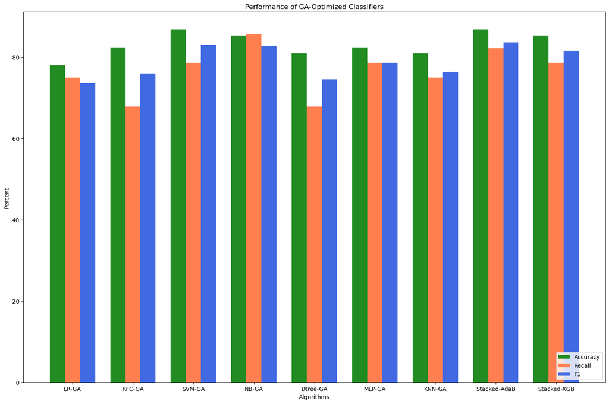

```python
# Plot the results
fig, ax = plt.subplots(figsize=(15, 10))

# Convert the DataFrame to plot
df_plot = results_df.copy()
df_plot['Accuracy'] = df_plot['Accuracy'] * 100
df_plot['Sensitivity'] = df_plot['Sensitivity'] * 100
df_plot['Specificity'] = df_plot['Specificity'] * 100
df_plot['F1'] = df_plot['F1 Score'] * 100

bar_width = 0.25
index = np.arange(len(df_plot))

bar1 = plt.bar(index, df_plot['Accuracy'], bar_width, label='Accuracy', color='forestgreen')
bar2 = plt.bar(index + bar_width, df_plot['Sensitivity'], bar_width, label='Recall', color='coral')
bar3 = plt.bar(index + 2 * bar_width, df_plot['F1'], bar_width, label='F1', color='royalblue')

plt.xlabel('Algorithms')
plt.ylabel('Percent')
plt.title('Performance of GA-Optimized Classifiers')
plt.xticks(index + 1 * bar_width, df_plot['Classifier Name'], rotation=0)
plt.legend(loc=4)

plt.tight_layout()
plt.show()
```

Now, we compare the performance of plain classifiers and a Stacked Genetic Algorithm (Stacked-GA) model using Holdout and K-fold cross-validation (2, 5, and 10 folds). The plain classifiers include Logistic Regression (LR), Random Forest (RF), Support Vector Machine (SVM), Naive Bayes (NB), Decision Tree (Dtree), Multi-Layer Perceptron (MLP), and K-Nearest Neighbors (KNN).

```python
# Evaluate each classifier using Holdout and K-fold cross-validation (2, 5, 10 folds)

# Classifiers
plain_classifiers = {
    'LR': LogisticRegression(max_iter=1000),
    'RF': RandomForestClassifier(),
    'SVM': SVC(probability=True),
    'NB': GaussianNB(),
    'Dtree': DecisionTreeClassifier(),
    'MLP': MLPClassifier(max_iter=2000, learning_rate_init=0.001, early_stopping=True, n_iter_no_change=10),
    'KNN': KNeighborsClassifier()
}

def calculate_sensitivity_specificity_f1(y_true, y_pred):
    tn, fp, fn, tp = confusion_matrix(y_true, y_pred).ravel()
    sensitivity = tp / (tp + fn) if (tp + fn) > 0 else 0
    specificity = tn / (tn + fp) if (tn + fp) > 0 else 0
    f1 = f1_score(y_true, y_pred)
    return sensitivity, specificity, f1

def evaluate_classifier(clf, X_train, y_train, X_test, y_test):
    clf.fit(X_train, y_train)
    y_pred = clf.predict(X_test)
    accuracy = accuracy_score(y_test, y_pred)
    sensitivity, specificity, f1 = calculate_sensitivity_specificity_f1(y_test, y_pred)
    return accuracy, sensitivity, specificity, f1

def evaluate_kfold(clf, X, y, k):
    kf = KFold(n_splits=k)
    accuracies = []
    sensitivities = []
    specificities = []
    f1_scores = []
    for train_idx, test_idx in kf.split(X):
        X_train, X_test = X[train_idx], X[test_idx]
        y_train, y_test = y.to_numpy()[train_idx], y.to_numpy()[test_idx]  # Convert y to numpy arrays
        clf.fit(X_train, y_train)
        y_pred = clf.predict(X_test)
        accuracy = accuracy_score(y_test, y_pred)
        sensitivity, specificity, f1 = calculate_sensitivity_specificity_f1(y_test, y_pred)
        accuracies.append(accuracy)
        sensitivities.append(sensitivity)
        specificities.append(specificity)
        f1_scores.append(f1)
    return np.mean(accuracies) * 100, np.mean(sensitivities) * 100, np.mean(specificities) * 100, np.mean(f1_scores) * 100


# Perform evaluations for all classifiers
results_kf = []
```

```python
# Evaluate plain classifiers
random.seed(seed_value)
for clf_name, clf in plain_classifiers.items():
    # Holdout evaluation
    accuracy, sensitivity, specificity, f1 = evaluate_classifier(clf, X_train_scaled, y_train, X_test_scaled, y_test)
    result = {
        'Model': clf_name,
        'ACC_Holdout': accuracy * 100,
        'Sen_Holdout': sensitivity * 100,
        'Spec_Holdout': specificity * 100,
        'F1_Holdout': f1 * 100
    }

    # K-fold evaluations
    acc_kf2, sen_kf2, spec_kf2, f1_kf2 = evaluate_kfold(clf, X_train_scaled, y_train, 2)
    acc_kf5, sen_kf5, spec_kf5, f1_kf5 = evaluate_kfold(clf, X_train_scaled, y_train, 5)
    acc_kf10, sen_kf10, spec_kf10, f1_kf10 = evaluate_kfold(clf, X_train_scaled, y_train, 10)

    result.update({
        'ACC_KF2': acc_kf2,
        'Sen_KF2': sen_kf2,
        'Spec_KF2': spec_kf2,
        'F1_KF2': f1_kf2,
        'ACC_KF5': acc_kf5,
        'Sen_KF5': sen_kf5,
        'Spec_KF5': spec_kf5,
        'F1_KF5': f1_kf5,
        'ACC_KF10': acc_kf10,
        'Sen_KF10': sen_kf10,
        'Spec_KF10': spec_kf10,
        'F1_KF10': f1_kf10
    })

    results_kf.append(result)

results_kf_table = pd.DataFrame(results_kf)
```

Generate cross-valiation for Stacked-GA (AdaBoost and XGBoost) as well as base XGBoost to append to the results_kf_table.

```python
# Perform Holdout and K-fold evaluation for Stacked-AdaBoost
meta_clf = AdaBoostClassifier(algorithm='SAMME')
meta_clf.fit(stacked_features, y_train)
y_pred = meta_clf.predict(stacked_test_features)
stacked_accuracy = accuracy_score(y_test, y_pred)
stacked_sensitivity, stacked_specificity, stacked_f1 = calculate_sensitivity_specificity_f1(y_test, y_pred)

stacked_holdout_results = {
    'Model': 'Stacked-AdaB',
    'ACC_Holdout': stacked_accuracy * 100,
    'Sen_Holdout': stacked_sensitivity * 100,
    'Spec_Holdout': stacked_specificity * 100,
    'F1_Holdout': stacked_f1 * 100
}

# K-fold evaluations for Stacked-GA
acc_kf2, sen_kf2, spec_kf2, f1_kf2 = evaluate_kfold(meta_clf, stacked_features, y_train, 2)
acc_kf5, sen_kf5, spec_kf5, f1_kf5 = evaluate_kfold(meta_clf, stacked_features, y_train, 5)
acc_kf10, sen_kf10, spec_kf10, f1_kf10 = evaluate_kfold(meta_clf, stacked_features, y_train, 10)

stacked_results_GA = {
    'Model': 'Stacked-AdaB',
    'ACC_Holdout': stacked_accuracy * 100,
    'Sen_Holdout': stacked_sensitivity * 100,
    'Spec_Holdout': stacked_specificity * 100,
    'F1_Holdout': stacked_f1 * 100,
    'ACC_KF2': acc_kf2,
    'Sen_KF2': sen_kf2,
    'Spec_KF2': spec_kf2,
    'F1_KF2': f1_kf2,
    'ACC_KF5': acc_kf5,
    'Sen_KF5': sen_kf5,
    'Spec_KF5': spec_kf5,
    'F1_KF5': f1_kf5,
    'ACC_KF10': acc_kf10,
    'Sen_KF10': sen_kf10,
    'Spec_KF10': spec_kf10,
    'F1_KF10': f1_kf10
}

# Append Stacked-AdaBoost results to results_kf_table
results_kf_table = pd.concat([results_kf_table, pd.DataFrame([stacked_results_GA])], ignore_index=True)

# Perform Stacked-XGBoost evaluations
meta_model_xgb = xgb.XGBClassifier(eval_metric='logloss', n_estimators=50, max_depth=3)
meta_model_xgb.fit(stacked_features, y_train)

# Holdout
y_pred = meta_model_xgb.predict(stacked_test_features)
stacked_xgb_accuracy = accuracy_score(y_test, y_pred)
stacked_xgb_sensitivity, stacked_xgb_specificity, stacked_xgb_f1 = calculate_sensitivity_specificity_f1(y_test, y_pred)

stacked_xgb_holdout_results = {
    'Model': 'Stacked-XGB',
    'ACC_Holdout': stacked_xgb_accuracy * 100,
    'Sen_Holdout': stacked_xgb_sensitivity * 100,
    'Spec_Holdout': stacked_xgb_specificity * 100,
    'F1_Holdout': stacked_xgb_f1 * 100
}

# K-fold evaluations for Stacked-XGBoost
acc_kf2, sen_kf2, spec_kf2, f1_kf2 = evaluate_kfold(meta_model_xgb, stacked_features, y_train, 2)
acc_kf5, sen_kf5, spec_kf5, f1_kf5 = evaluate_kfold(meta_model_xgb, stacked_features, y_train, 5)
acc_kf10, sen_kf10, spec_kf10, f1_kf10 = evaluate_kfold(meta_model_xgb, stacked_features, y_train, 10)

stacked_xgb_results = {
    'Model': 'Stacked-XGB',
    'ACC_Holdout': stacked_xgb_accuracy * 100,
    'Sen_Holdout': stacked_xgb_sensitivity * 100,
    'Spec_Holdout': stacked_xgb_specificity * 100,
    'F1_Holdout': stacked_xgb_f1 * 100,
    'ACC_KF2': acc_kf2,
    'Sen_KF2': sen_kf2,
    'Spec_KF2': spec_kf2,
    'F1_KF2': f1_kf2,
    'ACC_KF5': acc_kf5,
    'Sen_KF5': sen_kf5,
    'Spec_KF5': spec_kf5,
    'F1_KF5': f1_kf5,
    'ACC_KF10': acc_kf10,
    'Sen_KF10': sen_kf10,
    'Spec_KF10': spec_kf10,
    'F1_KF10': f1_kf10
}

# Append Stacked-XGBoost results to results_kf_table
results_kf_table = pd.concat([results_kf_table, pd.DataFrame([stacked_xgb_results])], ignore_index=True)
results_kf_table
```

|  | Model | ACC_Holdout | Sen_Holdout | Spec_Holdout | F1_Holdout | ACC_KF2 | Sen_KF2 | Spec_KF2 | F1_KF2 | ACC_KF5 | Sen_KF5 | Spec_KF5 | F1_KF5 | ACC_KF10 | Sen_KF10 | Spec_KF10 | F1_KF10 |
| --- | --- | --- | --- | --- | --- | --- | --- | --- | --- | --- | --- | --- | --- | --- | --- | --- | --- |
| 0 | LR | 85.294118 | 82.142857 | 87.5 | 82.142857 | 78.712871 | 74.711538 | 82.000669 | 75.802469 | 80.207317 | 75.702614 | 84.226285 | 76.659174 | 80.285714 | 76.921856 | 84.061855 | 76.426095 |
| 1 | RF | 77.941176 | 64.285714 | 87.5 | 70.588235 | 76.732673 | 72.115385 | 81.180997 | 73.644578 | 81.707317 | 78.081699 | 84.830698 | 78.727174 | 80.761905 | 76.807387 | 84.907093 | 77.163753 |
| 2 | SVM | 83.823529 | 82.142857 | 85.0 | 80.701754 | 80.198020 | 77.500000 | 82.820341 | 77.948156 | 84.170732 | 79.258170 | 88.368709 | 81.593824 | 82.761905 | 78.826618 | 86.406843 | 79.652212 |
| 3 | NB | 86.764706 | 82.142857 | 90.0 | 83.636364 | 81.188119 | 80.096154 | 82.000669 | 79.096970 | 83.170732 | 81.424837 | 85.095850 | 80.876346 | 82.738095 | 82.338523 | 83.959291 | 80.448000 |
| 4 | Dtree | 76.470588 | 64.285714 | 85.0 | 69.230769 | 66.831683 | 63.269231 | 71.144195 | 63.297491 | 72.365854 | 72.107843 | 71.802437 | 69.835026 | 75.285714 | 71.500611 | 75.856727 | 69.819789 |
| 5 | MLP | 85.294118 | 78.571429 | 90.0 | 81.481481 | 66.336634 | 69.519231 | 64.218802 | 65.133895 | 73.829268 | 75.990196 | 74.272398 | 72.522704 | 73.500000 | 64.065934 | 83.545788 | 65.035366 |
| 6 | KNN | 83.823529 | 82.142857 | 85.0 | 80.701754 | 80.693069 | 76.250000 | 84.660422 | 78.067523 | 83.219512 | 79.970588 | 85.905336 | 80.731458 | 81.809524 | 79.862943 | 84.338911 | 79.112078 |
| 7 | Stacked-AdaB | 86.764706 | 82.142857 | 90.0 | 83.636364 | 81.188119 | 76.923077 | 85.061894 | 78.422101 | 83.719512 | 81.267974 | 85.980698 | 81.136800 | 84.738095 | 79.595849 | 88.815934 | 81.778315 |
| 8 | Stacked-XGB | 85.294118 | 78.571429 | 90.0 | 81.481481 | 80.198020 | 73.750000 | 86.082302 | 76.855101 | 79.719512 | 75.591503 | 84.483992 | 76.715050 | 80.809524 | 75.191087 | 84.459291 | 76.836515 |

```python
# Perform AdaBoost directly without GA
ada_model = AdaBoostClassifier(algorithm='SAMME')
ada_model.fit(X_train_scaled, y_train)

# Holdout
accuracy, sensitivity, specificity, f1 = evaluate_classifier(ada_model, X_train_scaled, y_train, X_test_scaled, y_test)
xgb_holdout_results = {
    'Model': 'AdaBoost',
    'ACC_Holdout': accuracy * 100,
    'Sen_Holdout': sensitivity * 100,
    'Spec_Holdout': specificity * 100,
    'F1_Holdout': f1 * 100
}

# K-fold evaluations for AdaBoost
acc_kf2, sen_kf2, spec_kf2, f1_kf2 = evaluate_kfold(ada_model, X_train_scaled, y_train, 2)
acc_kf5, sen_kf5, spec_kf5, f1_kf5 = evaluate_kfold(ada_model, X_train_scaled, y_train, 5)
acc_kf10, sen_kf10, spec_kf10, f1_kf10 = evaluate_kfold(ada_model, X_train_scaled, y_train, 10)

adb_results = {
    'Model': 'AdaBoost',
    'ACC_Holdout': accuracy * 100,
    'Sen_Holdout': sensitivity * 100,
    'Spec_Holdout': specificity * 100,
    'F1_Holdout': f1 * 100,
    'ACC_KF2': acc_kf2,
    'Sen_KF2': sen_kf2,
    'Spec_KF2': spec_kf2,
    'F1_KF2': f1_kf2,
    'ACC_KF5': acc_kf5,
    'Sen_KF5': sen_kf5,
    'Spec_KF5': spec_kf5,
    'F1_KF5': f1_kf5,
    'ACC_KF10': acc_kf10,
    'Sen_KF10': sen_kf10,
    'Spec_KF10': spec_kf10,
    'F1_KF10': f1_kf10
}

# Append AdaBoost results to results_kf_table
results_kf_table = pd.concat([results_kf_table, pd.DataFrame([adb_results])], ignore_index=True)



# Perform XGBoost directly without GA
model = xgb.XGBClassifier(eval_metric='logloss', n_estimators=50, max_depth=3)
model.fit(X_train_scaled, y_train)

# Holdout
accuracy, sensitivity, specificity, f1 = evaluate_classifier(model, X_train_scaled, y_train, X_test_scaled, y_test)
xgb_holdout_results = {
    'Model': 'XGBoost',
    'ACC_Holdout': accuracy * 100,
    'Sen_Holdout': sensitivity * 100,
    'Spec_Holdout': specificity * 100,
    'F1_Holdout': f1 * 100
}

# K-fold evaluations for XGBoost
acc_kf2, sen_kf2, spec_kf2, f1_kf2 = evaluate_kfold(model, X_train_scaled, y_train, 2)
acc_kf5, sen_kf5, spec_kf5, f1_kf5 = evaluate_kfold(model, X_train_scaled, y_train, 5)
acc_kf10, sen_kf10, spec_kf10, f1_kf10 = evaluate_kfold(model, X_train_scaled, y_train, 10)

xgb_results = {
    'Model': 'XGBoost',
    'ACC_Holdout': accuracy * 100,
    'Sen_Holdout': sensitivity * 100,
    'Spec_Holdout': specificity * 100,
    'F1_Holdout': f1 * 100,
    'ACC_KF2': acc_kf2,
    'Sen_KF2': sen_kf2,
    'Spec_KF2': spec_kf2,
    'F1_KF2': f1_kf2,
    'ACC_KF5': acc_kf5,
    'Sen_KF5': sen_kf5,
    'Spec_KF5': spec_kf5,
    'F1_KF5': f1_kf5,
    'ACC_KF10': acc_kf10,
    'Sen_KF10': sen_kf10,
    'Spec_KF10': spec_kf10,
    'F1_KF10': f1_kf10
}

# Append XGBoost results to results_kf_table
results_kf_table = pd.concat([results_kf_table, pd.DataFrame([xgb_results])], ignore_index=True)
results_kf_table
```

|  | Model | ACC_Holdout | Sen_Holdout | Spec_Holdout | F1_Holdout | ACC_KF2 | Sen_KF2 | Spec_KF2 | F1_KF2 | ACC_KF5 | Sen_KF5 | Spec_KF5 | F1_KF5 | ACC_KF10 | Sen_KF10 | Spec_KF10 | F1_KF10 |
| --- | --- | --- | --- | --- | --- | --- | --- | --- | --- | --- | --- | --- | --- | --- | --- | --- | --- |
| 0 | LR | 85.294118 | 82.142857 | 87.5 | 82.142857 | 78.712871 | 74.711538 | 82.000669 | 75.802469 | 80.207317 | 75.702614 | 84.226285 | 76.659174 | 80.285714 | 76.921856 | 84.061855 | 76.426095 |
| 1 | RF | 77.941176 | 64.285714 | 87.5 | 70.588235 | 76.732673 | 72.115385 | 81.180997 | 73.644578 | 81.707317 | 78.081699 | 84.830698 | 78.727174 | 80.761905 | 76.807387 | 84.907093 | 77.163753 |
| 2 | SVM | 83.823529 | 82.142857 | 85.0 | 80.701754 | 80.198020 | 77.500000 | 82.820341 | 77.948156 | 84.170732 | 79.258170 | 88.368709 | 81.593824 | 82.761905 | 78.826618 | 86.406843 | 79.652212 |
| 3 | NB | 86.764706 | 82.142857 | 90.0 | 83.636364 | 81.188119 | 80.096154 | 82.000669 | 79.096970 | 83.170732 | 81.424837 | 85.095850 | 80.876346 | 82.738095 | 82.338523 | 83.959291 | 80.448000 |
| 4 | Dtree | 76.470588 | 64.285714 | 85.0 | 69.230769 | 66.831683 | 63.269231 | 71.144195 | 63.297491 | 72.365854 | 72.107843 | 71.802437 | 69.835026 | 75.285714 | 71.500611 | 75.856727 | 69.819789 |
| 5 | MLP | 85.294118 | 78.571429 | 90.0 | 81.481481 | 66.336634 | 69.519231 | 64.218802 | 65.133895 | 73.829268 | 75.990196 | 74.272398 | 72.522704 | 73.500000 | 64.065934 | 83.545788 | 65.035366 |
| 6 | KNN | 83.823529 | 82.142857 | 85.0 | 80.701754 | 80.693069 | 76.250000 | 84.660422 | 78.067523 | 83.219512 | 79.970588 | 85.905336 | 80.731458 | 81.809524 | 79.862943 | 84.338911 | 79.112078 |
| 7 | Stacked-AdaB | 86.764706 | 82.142857 | 90.0 | 83.636364 | 81.188119 | 76.923077 | 85.061894 | 78.422101 | 83.719512 | 81.267974 | 85.980698 | 81.136800 | 84.738095 | 79.595849 | 88.815934 | 81.778315 |
| 8 | Stacked-XGB | 85.294118 | 78.571429 | 90.0 | 81.481481 | 80.198020 | 73.750000 | 86.082302 | 76.855101 | 79.719512 | 75.591503 | 84.483992 | 76.715050 | 80.809524 | 75.191087 | 84.459291 | 76.836515 |
| 9 | AdaBoost | 83.823529 | 75.000000 | 90.0 | 79.245283 | 76.732673 | 74.326923 | 79.140181 | 74.278499 | 79.231707 | 76.591503 | 81.802042 | 76.030888 | 79.785714 | 78.774420 | 81.160589 | 76.179767 |
| 10 | XGBoost | 80.882353 | 67.857143 | 90.0 | 74.509804 | 75.742574 | 73.076923 | 78.320509 | 73.088023 | 76.268293 | 73.424837 | 77.674901 | 72.853670 | 77.761905 | 74.807387 | 79.971195 | 74.169447 |

Below is the code to generate an recall graph comparing the performance of plain classifiers with Stacked-GA (Adaboost), similar to the one in the paper. Stacked-GA with XGBoost and base XGBoost is also shown.

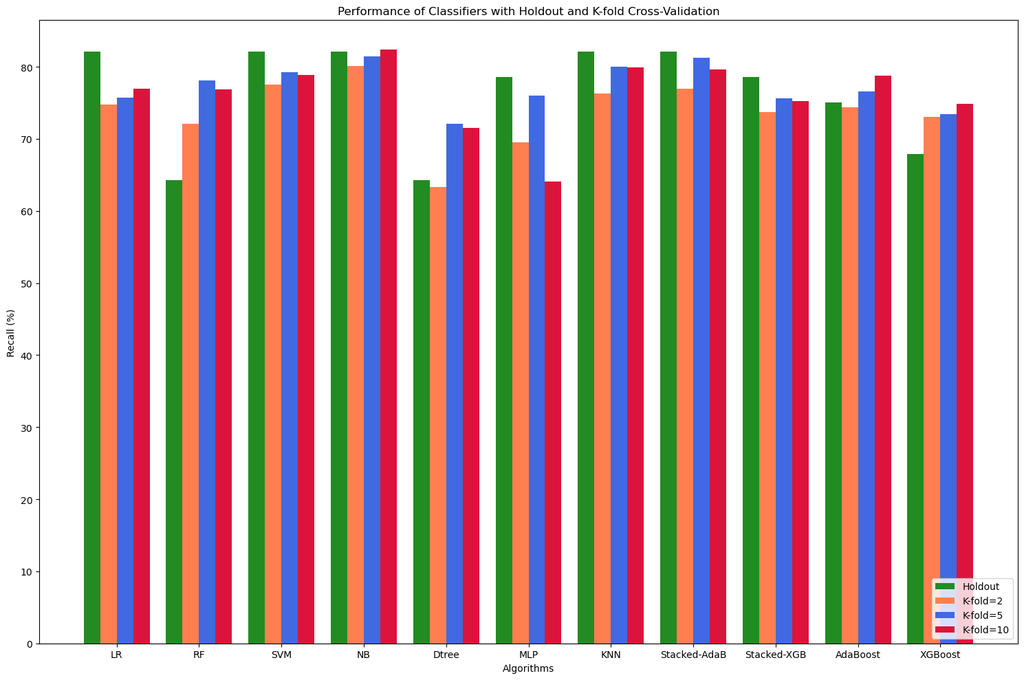

```python
# Plot the graph with Ada/XGBoost results
fig, ax = plt.subplots(figsize=(15, 10))
bar_width = 0.2
index = np.arange(len(results_kf_table))

bar1 = plt.bar(index, results_kf_table['Sen_Holdout'], bar_width, label='Holdout', color='forestgreen')
bar2 = plt.bar(index + bar_width, results_kf_table['Sen_KF2'], bar_width, label='K-fold=2', color='coral')
bar3 = plt.bar(index + 2 * bar_width, results_kf_table['Sen_KF5'], bar_width, label='K-fold=5', color='royalblue')
bar4 = plt.bar(index + 3 * bar_width, results_kf_table['Sen_KF10'], bar_width, label='K-fold=10', color='crimson')

plt.xlabel('Algorithms')
plt.ylabel('Recall (%)')
plt.title('Performance of Classifiers with Holdout and K-fold Cross-Validation')
plt.xticks(index + 1.5 * bar_width, results_kf_table['Model'], rotation=0)
plt.legend(loc=4)

plt.tight_layout()
plt.show()
```